```python
from sklearn.cluster import KMeans, DBSCAN
from sklearn.metrics import silhouette_samples, silhouette_score
from sklearn.preprocessing import StandardScaler,MinMaxScaler
from sklearn.decomposition import PCA
import matplotlib.pyplot as plt
import seaborn as sns
import pandas as pd
import numpy as np
```

# Part 1 - K-Means

```python
ins_path = 'D:/Data Mining/CA/3/car_insurance.csv'
ins_df = pd.read_csv(ins_path)
```

```python
ins_df.head()
```

|  | ID | KIDSDRIV | BIRTH | AGE | HOMEKIDS | YOJ | INCOME | PARENT1 | HOME_VAL | MSTATUS | ... | CAR_TYPE | RED_CAR | OLDCLAIM | CLM_FREQ | REVOKED | MVR_PTS | CLM_AMT | CAR_AGE | CLAIM_FLAG | URBANICITY |
| --- | --- | --- | --- | --- | --- | --- | --- | --- | --- | --- | --- | --- | --- | --- | --- | --- | --- | --- | --- | --- | --- |
| 0 | 63581743 | 0 | 16MAR39 | 60.0 | 0 | 11.0 | $67,349 | No | $0 | z_No | ... | Minivan | yes | $4,461 | 2 | No | 3 | $0 | 18.0 | 0 | Highly Urban/ Urban |
| 1 | 132761049 | 0 | 21JAN56 | 43.0 | 0 | 11.0 | $91,449 | No | $257,252 | z_No | ... | Minivan | yes | $0 | 0 | No | 0 | $0 | 1.0 | 0 | Highly Urban/ Urban |
| 2 | 921317019 | 0 | 18NOV51 | 48.0 | 0 | 11.0 | $52,881 | No | $0 | z_No | ... | Van | yes | $0 | 0 | No | 2 | $0 | 10.0 | 0 | Highly Urban/ Urban |
| 3 | 727598473 | 0 | 05MAR64 | 35.0 | 1 | 10.0 | $16,039 | No | $124,191 | Yes | ... | z_SUV | no | $38,690 | 2 | No | 3 | $0 | 10.0 | 0 | Highly Urban/ Urban |
| 4 | 450221861 | 0 | 05JUN48 | 51.0 | 0 | 14.0 | NaN | No | $306,251 | Yes | ... | Minivan | yes | $0 | 0 | No | 0 | $0 | 6.0 | 0 | Highly Urban/ Urban |

5 rows × 27 columns

We need to perform some preprocessing steps before applying KMeans.

- Handling Missing Values
- Encoding Categorical Features
- Normalizing features
- Reducing Dimensionality
- Handling Noise and Outlier

## Preprocessing

First, let's see how many features we have and what their types are. We have 27 columns, one of which is ID. Most of the features are categorical.

```python
ins_df.info()
```

```
<class 'pandas.core.frame.DataFrame'>
RangeIndex: 10302 entries, 0 to 10301
Data columns (total 27 columns):
 #   Column      Non-Null Count  Dtype
---  ------      --------------  -----
 0   ID          10302 non-null  int64
 1   KIDSDRIV    10302 non-null  int64
 2   BIRTH       10302 non-null  object
 3   AGE         10295 non-null  float64
 4   HOMEKIDS    10302 non-null  int64
 5   YOJ         9754 non-null   float64
 6   INCOME      9732 non-null   object
 7   PARENT1     10302 non-null  object
 8   HOME_VAL    9727 non-null   object
 9   MSTATUS     10302 non-null  object
```

[output cut: 19 more lines]

As we can see, some attributes like income, which are inherently numerical, are defined as objects. We should convert them to floats by removing $ and,.

```python
import re
cols = ['INCOME', 'OLDCLAIM','HOME_VAL','CLM_AMT', 'BLUEBOOK']
for c in cols:
    ins_df[c] = ins_df[ins_df[c].notna()][c].apply(lambda x: re.sub('[$,]','',x)).astype('float64')
ins_df
```

|  | ID | KIDSDRIV | BIRTH | AGE | HOMEKIDS | YOJ | INCOME | PARENT1 | HOME_VAL | MSTATUS | ... | CAR_TYPE | RED_CAR | OLDCLAIM | CLM_FREQ | REVOKED | MVR_PTS | CLM_AMT | CAR_AGE | CLAIM_FLAG | URBANICITY |
| --- | --- | --- | --- | --- | --- | --- | --- | --- | --- | --- | --- | --- | --- | --- | --- | --- | --- | --- | --- | --- | --- |
| 0 | 63581743 | 0 | 16MAR39 | 60.0 | 0 | 11.0 | 67349.0 | No | 0.0 | z_No | ... | Minivan | yes | 4461.0 | 2 | No | 3 | 0.0 | 18.0 | 0 | Highly Urban/ Urban |
| 1 | 132761049 | 0 | 21JAN56 | 43.0 | 0 | 11.0 | 91449.0 | No | 257252.0 | z_No | ... | Minivan | yes | 0.0 | 0 | No | 0 | 0.0 | 1.0 | 0 | Highly Urban/ Urban |
| 2 | 921317019 | 0 | 18NOV51 | 48.0 | 0 | 11.0 | 52881.0 | No | 0.0 | z_No | ... | Van | yes | 0.0 | 0 | No | 2 | 0.0 | 10.0 | 0 | Highly Urban/ Urban |
| 3 | 727598473 | 0 | 05MAR64 | 35.0 | 1 | 10.0 | 16039.0 | No | 124191.0 | Yes | ... | z_SUV | no | 38690.0 | 2 | No | 3 | 0.0 | 10.0 | 0 | Highly Urban/ Urban |
| 4 | 450221861 | 0 | 05JUN48 | 51.0 | 0 | 14.0 | NaN | No | 306251.0 | Yes | ... | Minivan | yes | 0.0 | 0 | No | 0 | 0.0 | 6.0 | 0 | Highly Urban/ Urban |
| ... | ... | ... | ... | ... | ... | ... | ... | ... | ... | ... | ... | ... | ... | ... | ... | ... | ... | ... | ... | ... | ... |
| 10297 | 67790126 | 1 | 13AUG54 | 45.0 | 2 | 9.0 | 164669.0 | No | 386273.0 | Yes | ... | Minivan | no | 0.0 | 0 | No | 2 | 0.0 | 17.0 | 0 | Highly Urban/ Urban |
| 10298 | 61970712 | 0 | 17JUN53 | 46.0 | 0 | 9.0 | 107204.0 | No | 332591.0 | Yes | ... | Panel Truck | no | 0.0 | 0 | No | 0 | 0.0 | 1.0 | 0 | Highly Urban/ Urban |
| 10299 | 849208064 | 0 | 18JUN51 | 48.0 | 0 | 15.0 | 39837.0 | No | 170611.0 | Yes | ... | z_SUV | no | 0.0 | 0 | No | 0 | 0.0 | 1.0 | 0 | Highly Urban/ Urban |
| 10300 | 627828331 | 0 | 12DEC48 | 50.0 | 0 | 7.0 | 43445.0 | No | 149248.0 | Yes | ... | Minivan | no | 0.0 | 0 | No | 0 | 0.0 | 11.0 | 0 | Highly Urban/ Urban |
| 10301 | 680381960 | 0 | 27FEB47 | 52.0 | 0 | 11.0 | 53235.0 | No | 197017.0 | Yes | ... | Minivan | no | 0.0 | 0 | No | 0 | 0.0 | 9.0 | 0 | z_Highly Rural/ Rural |

10302 rows × 27 columns

We plot histograms to illustrate the distribution of data and outliers.

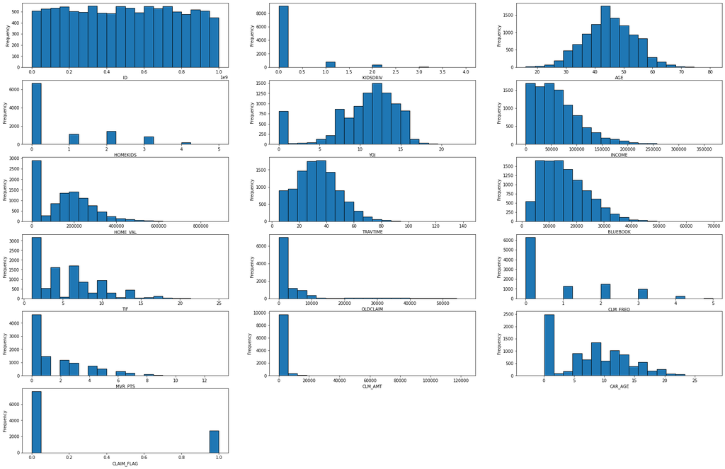

```python
plt.figure(figsize=(30,30))
cols = ins_df.select_dtypes(exclude='object').columns
for f in range(len(cols)):
    plt.subplot( 9, 3, f + 1)
    column = cols[f]
    plt.xlabel(column,loc='center')
    plt.ylabel("Frequency")
    plt.hist(ins_df[column], edgecolor='black', bins=20)
```

### Missing Values

KMeans cannot handle missing values, so we consider removing or replacing them.

```python
ins_df.isna().sum().sort_values(ascending=False) / ins_df.shape[0]
```

```
OCCUPATION    0.064551
CAR_AGE       0.062027
HOME_VAL      0.055814
INCOME        0.055329
YOJ           0.053194
AGE           0.000679
ID            0.000000
TIF           0.000000
CLAIM_FLAG    0.000000
CLM_AMT       0.000000
MVR_PTS       0.000000
REVOKED       0.000000
CLM_FREQ      0.000000
OLDCLAIM      0.000000
RED_CAR       0.000000
CAR_TYPE      0.000000
TRAVTIME      0.000000
BLUEBOOK      0.000000
CAR_USE       0.000000
KIDSDRIV      0.000000
EDUCATION     0.000000
GENDER        0.000000
MSTATUS       0.000000
PARENT1       0.000000
HOMEKIDS      0.000000
BIRTH         0.000000
URBANICITY    0.000000
dtype: float64
```

If features have an approximately normal distribution, we replace Nan with the average of the column. Otherwise, we use the median. For the remaining categorical columns, we replace Nan values with mode. If the number of missing values is small enough, we delete the corresponding rows.

```python
ins_df['OCCUPATION'].fillna(ins_df['OCCUPATION'].mode()[0], inplace = True)
ins_df.dropna(subset = ['AGE'], inplace = True)
ins_df['YOJ'].fillna(ins_df['YOJ'].median(), inplace = True)
ins_df['INCOME'].fillna(ins_df['INCOME'].median(), inplace = True)
ins_df['HOME_VAL'].fillna(ins_df['HOME_VAL'].median(), inplace = True)
ins_df['CAR_AGE'].fillna(ins_df['CAR_AGE'].median(), inplace = True)
```

### Drop Nonessential Columns

We remove the ID column first. Column BIRTH is unnecessary and the same as column AGE. We also drop columns that have unknown effects to reduce dimensionality. To determine whether any columns are highly correlated and potentially redundant, we create a heatmap.

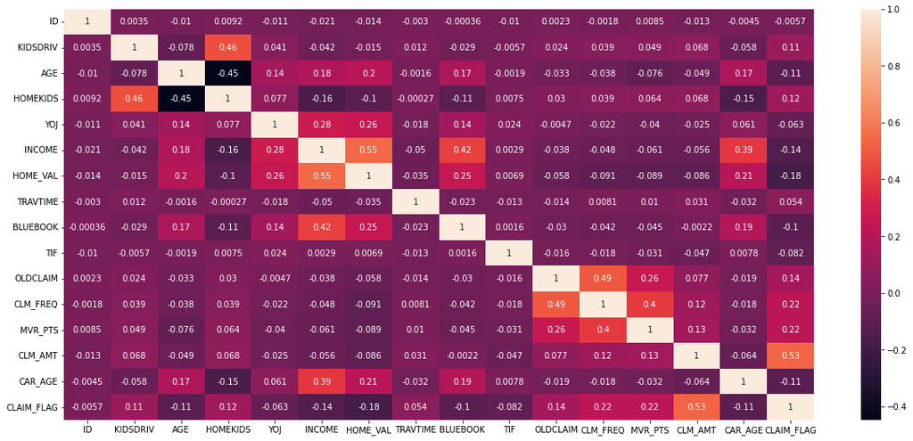

```python
plt.figure(figsize=(20,9))
corr1 = ins_df.corr()
sns.heatmap(corr1 ,annot=True)
plt.show()
```

```python
cols = ['BIRTH' , 'ID', 'CLAIM_FLAG',
         'CLM_AMT', 'URBANICITY','PARENT1','HOMEKIDS','CAR_AGE','CAR_TYPE','BLUEBOOK']
ins_df.drop(columns=cols , inplace=True)
```

### Convert Categorical to Numeric

Since KMeans only works with numeric features, we need to encode categorical columns into numerical. The occupation column is first divided into blue-collar and white-collar jobs based on the data description, and each one is assigned a numerical value.

```python
mask = (ins_df['OCCUPATION'] == 'z_Blue Collar')
ins_df.loc[mask, 'OCCUPATION'] = 1
ins_df.loc[-mask,'OCCUPATION'] = 0
ins_df
```

|  | KIDSDRIV | AGE | YOJ | INCOME | HOME_VAL | MSTATUS | GENDER | EDUCATION | OCCUPATION | TRAVTIME | CAR_USE | TIF | RED_CAR | OLDCLAIM | CLM_FREQ | REVOKED | MVR_PTS |
| --- | --- | --- | --- | --- | --- | --- | --- | --- | --- | --- | --- | --- | --- | --- | --- | --- | --- |
| 0 | 0 | 60.0 | 11.0 | 67349.0 | 0.0 | z_No | M | PhD | 0 | 14 | Private | 11 | yes | 4461.0 | 2 | No | 3 |
| 1 | 0 | 43.0 | 11.0 | 91449.0 | 257252.0 | z_No | M | z_High School | 1 | 22 | Commercial | 1 | yes | 0.0 | 0 | No | 0 |
| 2 | 0 | 48.0 | 11.0 | 52881.0 | 0.0 | z_No | M | Bachelors | 0 | 26 | Private | 1 | yes | 0.0 | 0 | No | 2 |
| 3 | 0 | 35.0 | 10.0 | 16039.0 | 124191.0 | Yes | z_F | z_High School | 0 | 5 | Private | 4 | no | 38690.0 | 2 | No | 3 |
| 4 | 0 | 51.0 | 14.0 | 53560.0 | 306251.0 | Yes | M | <High School | 1 | 32 | Private | 7 | yes | 0.0 | 0 | No | 0 |
| ... | ... | ... | ... | ... | ... | ... | ... | ... | ... | ... | ... | ... | ... | ... | ... | ... | ... |
| 10297 | 1 | 45.0 | 9.0 | 164669.0 | 386273.0 | Yes | M | PhD | 0 | 21 | Private | 15 | no | 0.0 | 0 | No | 2 |
| 10298 | 0 | 46.0 | 9.0 | 107204.0 | 332591.0 | Yes | M | Masters | 1 | 36 | Commercial | 6 | no | 0.0 | 0 | No | 0 |
| 10299 | 0 | 48.0 | 15.0 | 39837.0 | 170611.0 | Yes | z_F | <High School | 1 | 12 | Private | 7 | no | 0.0 | 0 | No | 0 |
| 10300 | 0 | 50.0 | 7.0 | 43445.0 | 149248.0 | Yes | z_F | Bachelors | 0 | 36 | Private | 6 | no | 0.0 | 0 | No | 0 |
| 10301 | 0 | 52.0 | 11.0 | 53235.0 | 197017.0 | Yes | z_F | z_High School | 0 | 64 | Private | 6 | no | 0.0 | 0 | No | 0 |

10295 rows × 17 columns

Since education is an ordinal data, we use an ordinal encoding to assign higher education a higher value.

```python
ins_df['EDUCATION'] = ins_df['EDUCATION'].map({'<High School': 0, 'z_High School': 1,
                                                'Bachelors': 2, 'Masters':3, 'PhD':4})
```

[output not shown]

For the remaining categorical features, we give each value a number. One-hot encoding is not used to avoid increasing dimension.

```python
for col in ins_df.select_dtypes('object'):
    ins_df[col] = ins_df[col].astype('category').cat.codes

num_df = ins_df.copy()
```

### Normalization

Since KMeans uses Euclidean distance to measure similarity between points, features with larger values will have a larger impact. We apply data scaling and normalization to avoid this. We use MinMaxScaler (min = 0, max = 1), which doesn't assume that the shape of all features follows a normal distribution. Also, better results have been achieved compared to StandardScaler.

```python
scaler = MinMaxScaler()
scaled_df = pd.DataFrame(scaler.fit_transform(num_df))
scaled_df
```

|  | 0 | 1 | 2 | 3 | 4 | 5 | 6 | 7 | 8 | 9 | 10 | 11 | 12 | 13 | 14 | 15 | 16 |
| --- | --- | --- | --- | --- | --- | --- | --- | --- | --- | --- | --- | --- | --- | --- | --- | --- | --- |
| 0 | 0.00 | 0.676923 | 0.478261 | 0.183497 | 0.000000 | 1.0 | 0.0 | 1.00 | 0.0 | 0.065693 | 1.0 | 0.416667 | 1.0 | 0.078212 | 0.4 | 0.0 | 0.230769 |
| 1 | 0.00 | 0.415385 | 0.478261 | 0.249159 | 0.290588 | 1.0 | 0.0 | 0.25 | 1.0 | 0.124088 | 0.0 | 0.000000 | 1.0 | 0.000000 | 0.0 | 0.0 | 0.000000 |
| 2 | 0.00 | 0.492308 | 0.478261 | 0.144078 | 0.000000 | 1.0 | 0.0 | 0.50 | 0.0 | 0.153285 | 1.0 | 0.000000 | 1.0 | 0.000000 | 0.0 | 0.0 | 0.153846 |
| 3 | 0.00 | 0.292308 | 0.434783 | 0.043699 | 0.140284 | 0.0 | 1.0 | 0.25 | 0.0 | 0.000000 | 1.0 | 0.125000 | 0.0 | 0.678332 | 0.4 | 0.0 | 0.230769 |
| 4 | 0.00 | 0.538462 | 0.608696 | 0.145928 | 0.345936 | 0.0 | 0.0 | 0.00 | 1.0 | 0.197080 | 1.0 | 0.250000 | 1.0 | 0.000000 | 0.0 | 0.0 | 0.000000 |
| ... | ... | ... | ... | ... | ... | ... | ... | ... | ... | ... | ... | ... | ... | ... | ... | ... | ... |
| 10290 | 0.25 | 0.446154 | 0.391304 | 0.448653 | 0.436328 | 0.0 | 0.0 | 1.00 | 0.0 | 0.116788 | 1.0 | 0.583333 | 0.0 | 0.000000 | 0.0 | 0.0 | 0.153846 |
| 10291 | 0.00 | 0.461538 | 0.391304 | 0.292085 | 0.375689 | 0.0 | 0.0 | 0.75 | 1.0 | 0.226277 | 0.0 | 0.208333 | 0.0 | 0.000000 | 0.0 | 0.0 | 0.000000 |
| 10292 | 0.00 | 0.492308 | 0.652174 | 0.108539 | 0.192719 | 0.0 | 1.0 | 0.00 | 1.0 | 0.051095 | 1.0 | 0.250000 | 0.0 | 0.000000 | 0.0 | 0.0 | 0.000000 |
| 10293 | 0.00 | 0.523077 | 0.304348 | 0.118369 | 0.168588 | 0.0 | 1.0 | 0.50 | 0.0 | 0.226277 | 1.0 | 0.208333 | 0.0 | 0.000000 | 0.0 | 0.0 | 0.000000 |
| 10294 | 0.00 | 0.553846 | 0.478261 | 0.145043 | 0.222547 | 0.0 | 1.0 | 0.25 | 0.0 | 0.430657 | 1.0 | 0.208333 | 0.0 | 0.000000 | 0.0 | 0.0 | 0.000000 |

10295 rows × 17 columns

### Outliers

Outliers may distract the centers of clusters and affect KMeans performance. To mitigate this effect, we used zscore with threshold 3 and considered points outside this threshold to be outliers and removed them.

```python
import scipy.stats as stats
z = np.abs(stats.zscore(scaled_df))
threshold = 3
new_ins_df = scaled_df[(z < threshold).all(axis=1)]
new_ins_df
```

|  | 0 | 1 | 2 | 3 | 4 | 5 | 6 | 7 | 8 | 9 | 10 | 11 | 12 | 13 | 14 | 15 | 16 |
| --- | --- | --- | --- | --- | --- | --- | --- | --- | --- | --- | --- | --- | --- | --- | --- | --- | --- |
| 0 | 0.00 | 0.676923 | 0.478261 | 0.183497 | 0.000000 | 1.0 | 0.0 | 1.00 | 0.0 | 0.065693 | 1.0 | 0.416667 | 1.0 | 0.078212 | 0.4 | 0.0 | 0.230769 |
| 1 | 0.00 | 0.415385 | 0.478261 | 0.249159 | 0.290588 | 1.0 | 0.0 | 0.25 | 1.0 | 0.124088 | 0.0 | 0.000000 | 1.0 | 0.000000 | 0.0 | 0.0 | 0.000000 |
| 2 | 0.00 | 0.492308 | 0.478261 | 0.144078 | 0.000000 | 1.0 | 0.0 | 0.50 | 0.0 | 0.153285 | 1.0 | 0.000000 | 1.0 | 0.000000 | 0.0 | 0.0 | 0.153846 |
| 4 | 0.00 | 0.538462 | 0.608696 | 0.145928 | 0.345936 | 0.0 | 0.0 | 0.00 | 1.0 | 0.197080 | 1.0 | 0.250000 | 1.0 | 0.000000 | 0.0 | 0.0 | 0.000000 |
| 5 | 0.00 | 0.523077 | 0.478261 | 0.313288 | 0.275534 | 0.0 | 1.0 | 1.00 | 0.0 | 0.226277 | 1.0 | 0.000000 | 0.0 | 0.336922 | 0.4 | 1.0 | 0.230769 |
| ... | ... | ... | ... | ... | ... | ... | ... | ... | ... | ... | ... | ... | ... | ... | ... | ... | ... |
| 10290 | 0.25 | 0.446154 | 0.391304 | 0.448653 | 0.436328 | 0.0 | 0.0 | 1.00 | 0.0 | 0.116788 | 1.0 | 0.583333 | 0.0 | 0.000000 | 0.0 | 0.0 | 0.153846 |
| 10291 | 0.00 | 0.461538 | 0.391304 | 0.292085 | 0.375689 | 0.0 | 0.0 | 0.75 | 1.0 | 0.226277 | 0.0 | 0.208333 | 0.0 | 0.000000 | 0.0 | 0.0 | 0.000000 |
| 10292 | 0.00 | 0.492308 | 0.652174 | 0.108539 | 0.192719 | 0.0 | 1.0 | 0.00 | 1.0 | 0.051095 | 1.0 | 0.250000 | 0.0 | 0.000000 | 0.0 | 0.0 | 0.000000 |
| 10293 | 0.00 | 0.523077 | 0.304348 | 0.118369 | 0.168588 | 0.0 | 1.0 | 0.50 | 0.0 | 0.226277 | 1.0 | 0.208333 | 0.0 | 0.000000 | 0.0 | 0.0 | 0.000000 |
| 10294 | 0.00 | 0.553846 | 0.478261 | 0.145043 | 0.222547 | 0.0 | 1.0 | 0.25 | 0.0 | 0.430657 | 1.0 | 0.208333 | 0.0 | 0.000000 | 0.0 | 0.0 | 0.000000 |

9093 rows × 17 columns

## Dimensionality Reduction

KMeans cannot scale up to high-dimensional data because the distance between any two data objects in a high-dimensional space is the same. We try dimensionality reduction techniques like PCA to address this issue. We tried running KMeans with different numbers of components. The best result happened when we had two components.

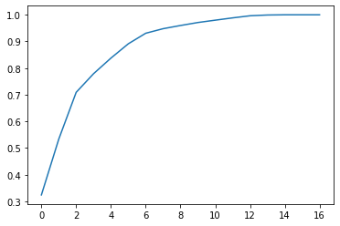

```python
pca = PCA()
pca.fit(new_ins_df)
cumsum = np.cumsum(pca.explained_variance_ratio_)
plt.plot(cumsum)
```

```python
def dim_red(scaled_df,n):
    if n > 1 :
        pca = PCA(n_components = n)
        data_pca = pca.fit_transform(scaled_df)
        return pd.DataFrame(data_pca)
    return scaled_df
```

## Silhouette

```python
from yellowbrick.cluster import SilhouetteVisualizer
```

```python
def plot_scores(k_values,scores,inertia):
    plt.figure(figsize = (20,10))
    plt.subplot(1,2,1)
    plt.plot(k_values, scores, marker = 'o')
    plt.xlabel("K")
    plt.ylabel("silhouette score")
    plt.title("Silhouette Score")

    plt.subplot(1,2,2)
    plt.plot(k_values, inertia, marker = 'o')
    plt.xlabel("K")
    plt.ylabel("Inertia")
    plt.title("Inertia")
```

```python
k_values = [k for k in range(2,10)]

def search_kmeans(X, k_values):
    scores = []
    inertia = []
    for k in k_values:
        kmeans = KMeans(n_clusters=k)
        y_pred = kmeans.fit_predict(X)
        labels = kmeans.labels_
        sc = silhouette_score(X, labels)
        scores.append(sc)
        inertia.append(kmeans.inertia_)
        visualizer = SilhouetteVisualizer(kmeans, colors='yellowbrick', is_fitted=True)
        visualizer.fit(X)
        visualizer.show()

    plot_scores(k_values,scores,inertia)
    return scores, inertia
```

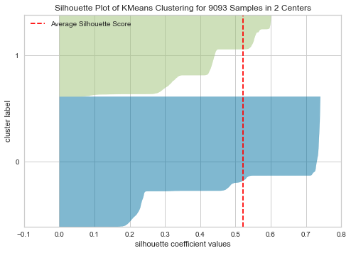

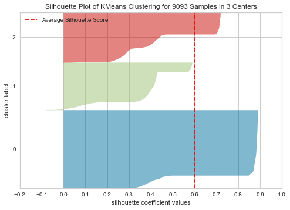

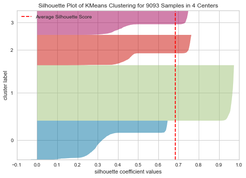

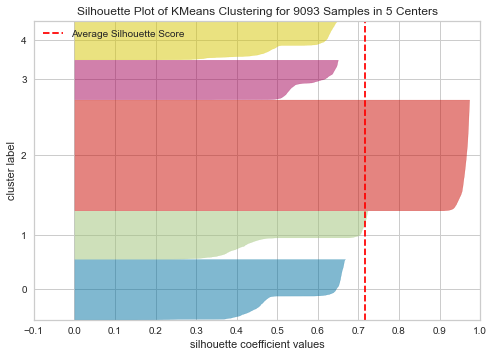

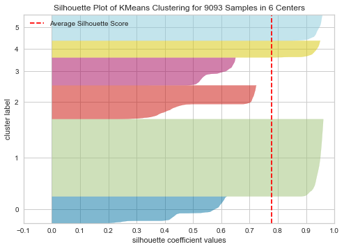

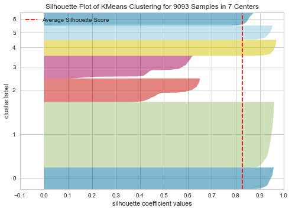

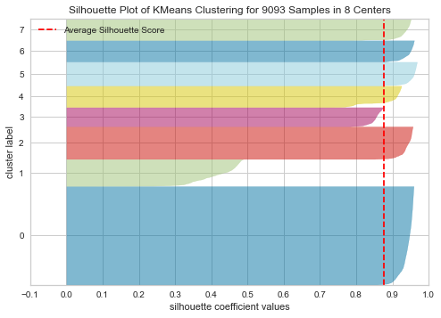

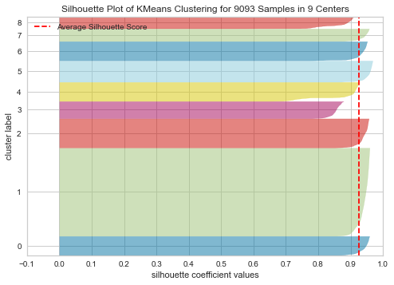

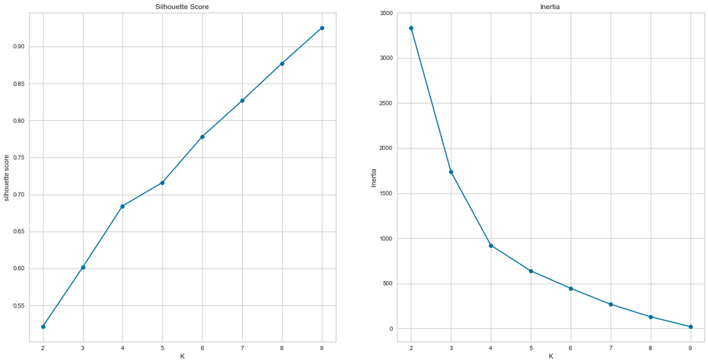

```python
X = dim_red(new_ins_df,2)
scores , inertia = search_kmeans(X,k_values)
```

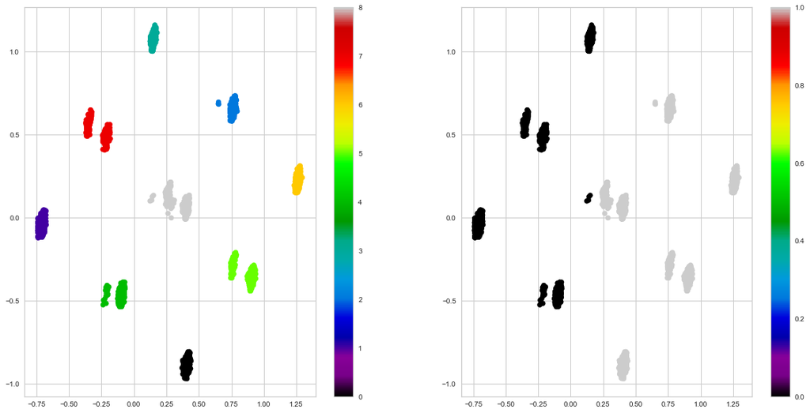

```python
plt.figure(figsize=(20,10))
kmeans = KMeans(n_clusters=9)
y_pred = kmeans.fit_predict(X)

plt.subplot(1,2,1)
plt.scatter(x = X[0] , y =  X[1], c= y_pred, cmap='nipy_spectral')
plt.colorbar()

plt.subplot(1,2,2)
kmeans = KMeans(n_clusters=2)
plt.scatter(x = X[0] , y =  X[1], c= kmeans.fit_predict(X), cmap='nipy_spectral')
plt.colorbar()
```

Finally, we executed KMeans with k ranging from 2 to 9 and displayed the silhouette coefficient for each sample per cluster to assess the density and distance between clusters. Clusters with higher scores have wider silhouettes, but clusters that are less cohesive will fall short of the average score across all clusters. We selected k = 9 based on this and the average score. Each color represent a distinct cluster.

# Part2 - DBSCAN

```python
eq_path = 'D:/Data Mining/CA/3/earthquake_ir.csv'
eq_df = pd.read_csv(eq_path)
eq_df.head()
```

|  | time | latitude | longitude | depth | mag | magType | nst | gap | dmin | rms | ... | updated | place | type | horizontalError | depthError | magError | magNst | status | locationSource | magSource |
| --- | --- | --- | --- | --- | --- | --- | --- | --- | --- | --- | --- | --- | --- | --- | --- | --- | --- | --- | --- | --- | --- |
| 0 | 2023-04-14T03:45:58.966Z | 32.0636 | 50.0818 | 10.0 | 4.5 | mb | 49.0 | 62.0 | 7.640 | 0.70 | ... | 2023-04-14T04:10:53.040Z | 50 km WSW of F?rs?n, Iran | earthquake | 3.40 | 1.869 | 0.081 | 45.0 | reviewed | us | us |
| 1 | 2023-04-07T23:38:12.647Z | 28.1032 | 56.9952 | 10.0 | 4.1 | mb | 55.0 | 51.0 | 3.224 | 0.49 | ... | 2023-04-16T03:29:38.040Z | 108 km N of M?n?b, Iran | earthquake | 4.98 | 1.882 | 0.088 | 35.0 | reviewed | us | us |
| 2 | 2023-04-04T14:53:08.017Z | 28.2978 | 56.9272 | 10.0 | 4.0 | mb | 25.0 | 144.0 | 3.401 | 0.94 | ... | 2023-04-04T16:27:10.040Z | 109 km S of K?h Sef?d, Iran | earthquake | 13.03 | 1.950 | 0.126 | 17.0 | reviewed | us | us |
| 3 | 2023-04-03T03:55:02.834Z | 28.0114 | 56.9150 | 10.0 | 4.3 | mb | 50.0 | 108.0 | 3.119 | 0.43 | ... | 2023-04-03T04:15:26.040Z | NaN | earthquake | 10.57 | 1.906 | 0.086 | 38.0 | reviewed | us | us |
| 4 | 2023-04-02T07:55:27.919Z | 27.1929 | 52.9741 | 10.0 | 4.4 | mb | 40.0 | 86.0 | 3.667 | 0.56 | ... | 2023-04-02T08:20:38.040Z | NaN | earthquake | 8.41 | 1.898 | 0.095 | 32.0 | reviewed | us | us |

5 rows × 22 columns

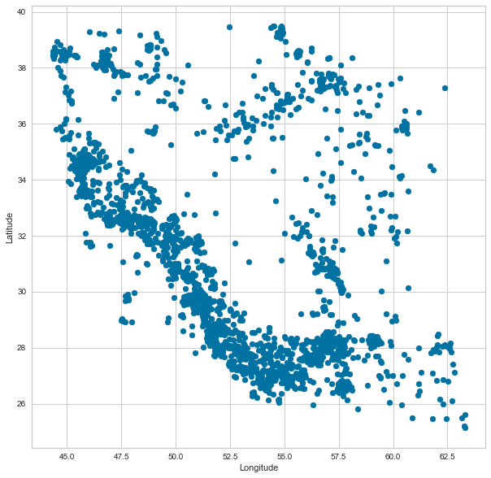

```python
loc_df = eq_df[['latitude', 'longitude']]
X = np.asarray(loc_df)
kms_per_radian = 6371.0
coordinates = np.radians(X)

plt.figure(figsize=(10,10))
plt.scatter(x = loc_df['longitude'] , y = loc_df['latitude'])
plt.xlabel('Longitude')
plt.ylabel('Latitude')
```

Plotting Kdist(k=4), to determine epsilon when min_points = 4

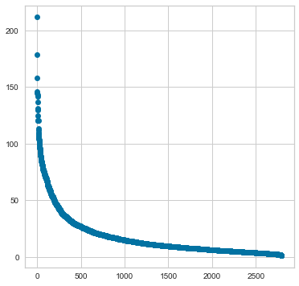

```python
from sklearn.metrics.pairwise import haversine_distances
result = haversine_distances(coordinates,coordinates)
dist = result * kms_per_radian
kdist = np.array([np.sort(d)[4] for d in dist])
plt.figure(figsize= (6,6))
plt.grid('both')
plt.plot(-np.sort(-kdist),'o')
```

We don't need to normalize longitude and latitude as we use haversine as a distance metric in DBSCAN. Haversine is used to determine the distance in kilometers between coordinate pairs. We give epsilon in kilometers and we should convert it into radians when applying haversine distance.

```python
def draw_sc(X,min_points,epsilon):

    scores = []
    plt.figure(figsize=(15,12))
    nrwos = len(min_points) // 4 + 1
    for p in range(len(min_points)):
        s = []
        for e in epsilon:
            dbscan = DBSCAN(eps= e/kms_per_radian, min_samples= min_points[p], algorithm = 'ball_tree', metric='haversine')
            dbscan.fit(X)
            labels = dbscan.labels_
            num_clusters = len(set(labels))
            if num_clusters > 1:
                sc = round(silhouette_score(X, labels),4)
            else:
                sc = 0
            s.append([min_points[p],e,sc,set(labels)])
            scores.append([min_points[p],e,sc,set(labels)])

        temp = np.array(s)
        plt.subplot(nrwos,4,p + 1)
        plt.plot(temp[:,1],temp[:,2])
        plt.title(f"min points = {min_points[p]}")
        plt.xlabel("epsilon")
        plt.ylabel("silhouette score")
    return pd.DataFrame(scores,columns=['min_points','epsilon','silhouette_score','clusters'])
```

First we executed DBSCAN with min_points ranging from 15 to 25 and epsilon ranging from 80 to 200 km. for each value chosen for min point we plotted average silhouette score. As we can see, the best score achieved when epsilon was approximately 170 km and min_points was around 20.

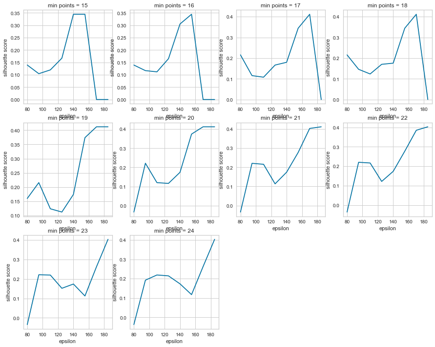

```python
min_points = [p for p in range(15,25)]
epsilon = [e for e in range(80,200,15)]
df1 = draw_sc(coordinates,min_points,epsilon)
```

This time, we executed DBSCAN with smaller min_points and an epsilon range. Silhouette score was negative in most executions when epsilon was below 100 km.

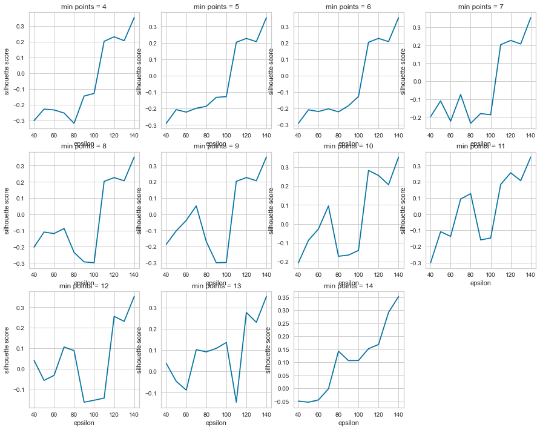

```python
min_points = [p for p in range(4,15)]
epsilon = [e for e in range(40,150,10)]
df2 = draw_sc(coordinates,min_points,epsilon)
```

The result is stored in a dataframe. You can see the highest silhouette score and all its associated parameters.

```python
sc_df = pd.concat([df1,df2],axis=0)
sc_df
```

|  | min_points | epsilon | silhouette_score | clusters |
| --- | --- | --- | --- | --- |
| 0 | 15 | 80 | 0.1393 | {0, 1, 2, 3, -1} |
| 1 | 15 | 95 | 0.1043 | {0, 1, 2, 3, 4, 5, -1} |
| 2 | 15 | 110 | 0.1196 | {0, 1, 2, 3, 4, -1} |
| 3 | 15 | 125 | 0.1670 | {0, 1, 2, -1} |
| 4 | 15 | 140 | 0.3443 | {0, -1} |
| ... | ... | ... | ... | ... |
| 116 | 14 | 100 | 0.1068 | {0, 1, 2, 3, 4, 5, 6, -1} |
| 117 | 14 | 110 | 0.1521 | {0, 1, 2, -1} |
| 118 | 14 | 120 | 0.1682 | {0, 1, 2, -1} |
| 119 | 14 | 130 | 0.2913 | {0, 1, -1} |
| 120 | 14 | 140 | 0.3524 | {0, -1} |

201 rows × 4 columns

```python
max = sc_df['silhouette_score'].max()
sc_df[sc_df['silhouette_score'] == max]
```

|  | min_points | epsilon | silhouette_score | clusters |
| --- | --- | --- | --- | --- |
| 22 | 17 | 170 | 0.4117 | {0, -1} |
| 30 | 18 | 170 | 0.4117 | {0, -1} |
| 38 | 19 | 170 | 0.4117 | {0, -1} |
| 39 | 19 | 185 | 0.4117 | {0, -1} |
| 46 | 20 | 170 | 0.4117 | {0, -1} |
| 47 | 20 | 185 | 0.4117 | {0, -1} |
| 55 | 21 | 185 | 0.4117 | {0, -1} |

```
min_point: 20 - sc:  0.4116802633593812
min_point: 15 - sc:  0.344263484846137
```

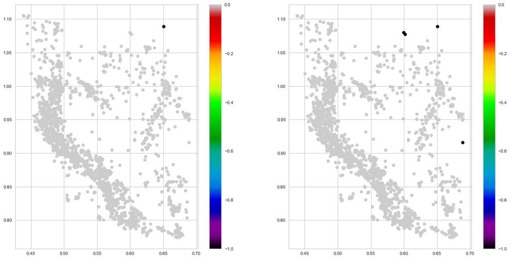

```python
dbscan_s = DBSCAN(eps= 170/kms_per_radian, min_samples=20, algorithm = 'ball_tree', metric='haversine')
dbscan_s.fit(coordinates)
labels_s = dbscan_s.labels_
print(f"min_point: {20} - sc: ",silhouette_score(coordinates,labels_s))

dbscan_l = DBSCAN(eps= 140/kms_per_radian, min_samples=15, algorithm = 'ball_tree', metric='haversine')
dbscan_l.fit(coordinates)
labels_l = dbscan_l.labels_
print(f"min_point: {15} - sc: ",silhouette_score(coordinates,labels_l))

plt.figure(figsize=(20,10))
plt.subplot(1,2,1)
plt.scatter(x = coordinates[:,0] , y =  coordinates[:,1], c= labels_s, cmap='nipy_spectral')
plt.colorbar()

plt.subplot(1,2,2)
plt.scatter(x = coordinates[:,0] , y =  coordinates[:,1], c= labels_l, cmap='nipy_spectral')
plt.colorbar()
```

## Epsilon Values

- If the epsilon is too **large**, the clusters will merge and no points considered to be noise(noises will become core points or border points).(right plot)
- If the epsilon is too **small**, if any cluster will form it would be small and many points will be considered noise.(left plot)

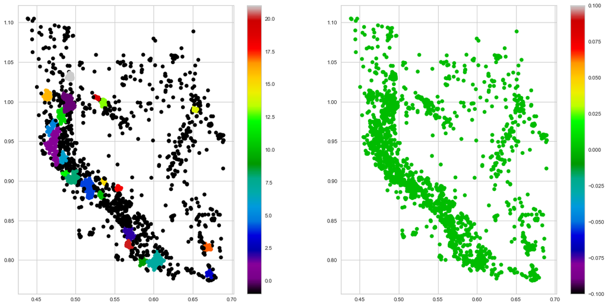

```python
dbscan_s = DBSCAN(eps= 20/kms_per_radian, min_samples=14, algorithm = 'ball_tree', metric='haversine')
dbscan_s.fit(coordinates)
labels_s = dbscan_s.labels_

dbscan_l = DBSCAN(eps= 250/kms_per_radian, min_samples=14, algorithm = 'ball_tree', metric='haversine')
dbscan_l.fit(coordinates)
labels_l = dbscan_l.labels_

plt.figure(figsize=(20,10))
plt.subplot(1,2,1)
plt.scatter(x = coordinates[:,0] , y =  coordinates[:,1], c= labels_s, cmap='nipy_spectral')
plt.colorbar()

plt.subplot(1,2,2)
plt.scatter(x = coordinates[:,0] , y =  coordinates[:,1], c= labels_l, cmap='nipy_spectral')
plt.colorbar()
```

## Min_points Values

- A very **large** value of min_points will result in many points being labeled as noise or very few dense clusters being formed.(right plot)
- A very **small** value of min_points will result in many small clusters being formed(noises will form small clusters) or clusters being merged together.(left plot)

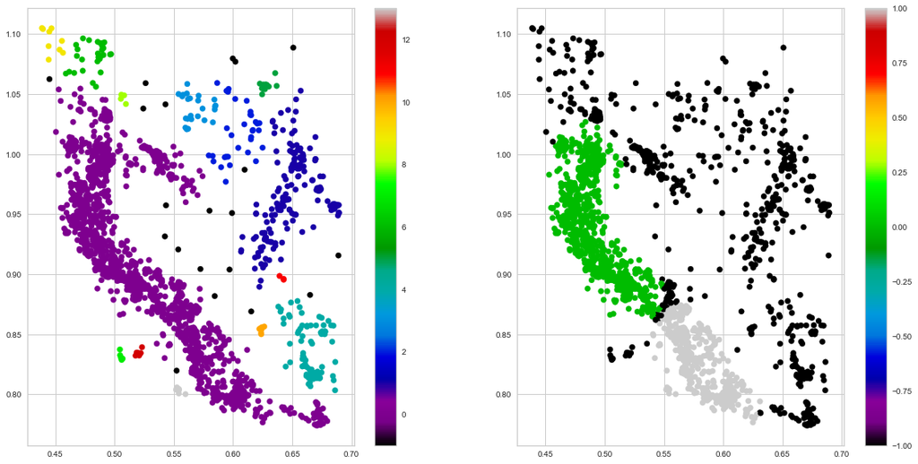

```python
dbscan_s = DBSCAN(eps= 70/kms_per_radian, min_samples=3, algorithm = 'ball_tree', metric='haversine')
dbscan_s.fit(coordinates)
labels_s = dbscan_s.labels_

dbscan_l = DBSCAN(eps= 120/kms_per_radian, min_samples=200, algorithm = 'ball_tree', metric='haversine')
dbscan_l.fit(coordinates)
labels_l = dbscan_l.labels_

plt.figure(figsize=(20,10))
plt.subplot(1,2,1)
plt.scatter(x = coordinates[:,0] , y =  coordinates[:,1], c= labels_s, cmap='nipy_spectral')
plt.colorbar()

plt.subplot(1,2,2)
plt.scatter(x = coordinates[:,0] , y =  coordinates[:,1], c= labels_l, cmap='nipy_spectral')
plt.colorbar()
```

From the scatter plot, we can see that there are clusters with different densities, and since the minpts and epsilon are the same for all clusters in DBSCAN, we think it's the reason why DBSCAN didn't work very well.

## New Feature

Looking at the attributes, the only attribute connected to the geographic location is 'place' which is a textual description of the location near to the earthquake. The 'place' attribute is made up of the names of the cities and countries where earthquakes happened. We can use Gower distance when we have mixed data (precompute the distance matrix in DBSCAN) or encode categorical data and use Euclidean distance. But, we decided not to add this feature.